# USMR Lecture 5

Doing statistics

Milan Valášek

## Before we start

- Any questions about last week’s matters?

## Today

- Doing stats on categorical variables and testing model fit
- Differences in means under ideal conditions
- Differences in means in the real world
- Type I and II errors
- Quantifying confidence
- Linear model revisited

# The $\chi^2$-test

## Modelling categorical data

- We talked about how the [$\chi^2$-distribution](https://mivalek.github.io/Lectures/pub/l4_pub.html#/chi2-distribution) is useful for assessing model fit.
- When working with categorical data, we can model their distributions
- $\chi^2$-test allows us to see how our *model distribution fits the data*
- By extension, we can model relationships between 2 categorical variables

## Goodness-of-fit test

- Let’s look at the representation of MSc study programmes in the first USMR lecture
- Out of 148 attendees, there were 41 CogSci, 52 LEL, and 55 Psych students
- Say we’re expecting equal representation of the three programmes – this is our $H_0$
- Is the split above due to random statistical fluctuations or is there a systematic difference between our expectation and observation?

## Goodness-of-fit test

```r
l1_data <- rep(c("cog", "lel", "psy"), c(41, 52, 55))
# expected frequencies
exp <- rep(length(l1_data) / length(unique(l1_data)),
           length(unique(l1_data))) # there are 3 unique values
names(exp) <- c("cog", "lel", "psy") # vectors can be named!

# see the observed distribution
table(l1_data)
l1_data
cog lel psy
 41  52  55
# and the expected one
exp
     cog      lel      psy
49.33333 49.33333 49.33333
```

## Goodness-of-fit test

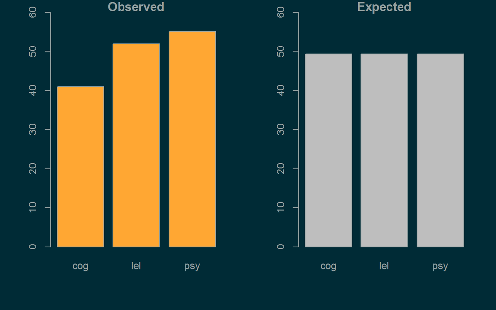

```r
par(mfrow = 1:2)
barplot(table(l1_data), ylim = c(0, 60),
        main = "Observed", col = colors[3])
barplot(exp, ylim = c(0, 60), main = "Expected")
```

```r
par(mfrow = c(1, 1))
```

## Goodness-of-fit test

- We can quantify how well our uniformity model fits the data [(full code)](https://mivalek.github.io/Lectures/pub/chisq_barplot.R)

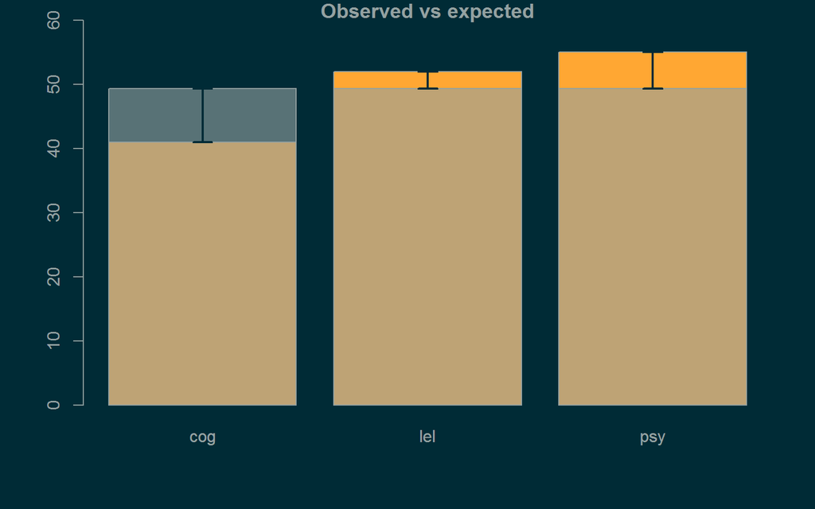

## Goodness-of-fit test

- We do this using the sum of **scaled** squares (sum of squared differences over expected frequencies)
- $\chi^2 = \sum\limits_{i=1}^n{\frac{(O_i - E_i)^2}{E_i}}$; where $n$ is the number of categories, $O_i$ is the observed frequency and $E_i$ the expected frequency of the $i$<sup>th</sup> category

```r
(diffs <- table(l1_data) - exp)
l1_data
      cog       lel       psy
-8.333333  2.666667  5.666667
(squares <- diffs^2)
l1_data
      cog       lel       psy
69.444444  7.111111 32.111111
(chi <- sum(squares/exp))
[1] 2.202703
```

## Goodness-of-fit test

- This is our test statistic
  - Because it’s a sum of squares (and because of its name!), we know that it follows a $\chi^2$-distribution
- We need to figure out how many degrees of freedom we have
  - There are 3 categories, each one with its own frequency
  - If we fix the number of data points to 148, the frequencies within how many categories vary freely?
  - $df = n-1$

## Goodness-of-fit test

- Before we rely on the theoretical $\chi^2$-distribution, let’s simulate the sampling distribution of our calculated $\chi^2$-statistic under the null

```r
# take 100,000 samples of 148 draws from
# a uniform distribution of the 3 programmes
pop <- replicate(10^5, sample(names(exp), 148, replace = T))

# define a function that calculates the chi^2 stat
chi_fun <- function(obser, expect) sum((table(obser) - expect)^2/expect)

# apply the function to each column of pop
chi_dist <- apply(pop, 2, function(x) chi_fun(x, exp))
```

## Goodness-of-fit test

[(full code)](https://mivalek.github.io/Lectures/pub/chisq_test.R)

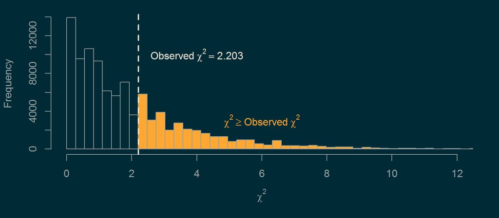

- We can use this distribution to get an **empirical** *p*-value – $p > .05$ so not significant

```r
# empirical p-value
sum(chi_dist >= chi)/length(chi_dist)
[1] 0.34077
```

## Goodness-of-fit test

- Is the $\chi^2$-distribution with 2 *df* a good approximation?

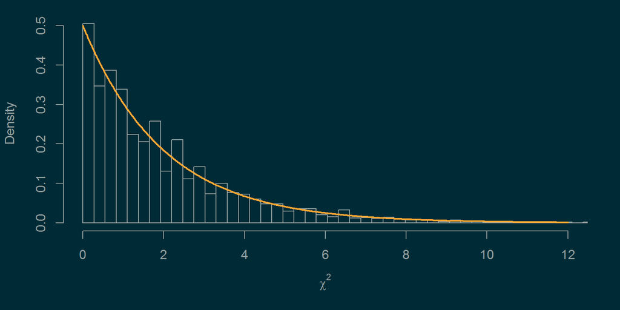

```r
hist(chi_dist, breaks = seq(0, 22, by = .275), main = "",
     xlab = expression(chi^2), xlim = c(0, 12), freq = F)
x <- seq(0, 12, length.out = 500)
lines(x, dchisq(x, 2), col = colors[3], lwd = 2)
```

## Goodness-of-fit test

- Let’s use it to calculate the *p*-value then!

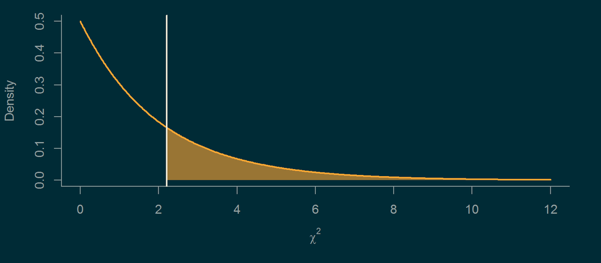

```r
# get probability that chi^2 >= observed value
pchisq(chi, 2, lower.tail = F)
[1] 0.3324216
# compare with empirical p-value
sum(chi_dist >= chi)/length(chi_dist)
[1] 0.34077
```

## Goodness-of-fit test

- Pearson’s $\chi^2$ goodness-of-fit test showed that the **distribution of study programme is not significantly different from uniform**, $\chi^2(2) = 2.203,\ p = .332$
- Of course we can do this very quickly in `R`

```r
chisq.test(table(l1_data))

    Chi-squared test for given probabilities

data:  table(l1_data)
X-squared = 2.2027, df = 2, p-value = 0.3324
```

## Goodness-of-fit test

- We used the $\chi^2$ goodness-of-fit test to see if our null hypothesis model distribution (uniform) is a good fit to the observed data
- We can however specify *any* model distribution, *e.g.,* a 35%-40%-25% split

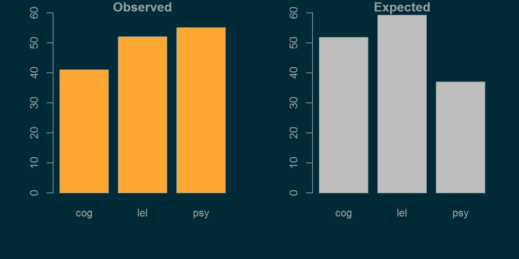

## Goodness-of-fit test

- This model distribution is not a good fit to the data
- The differences between observed and expected frequencies are too large, leading to a large value of the $\chi^2$-statistic

```r
chisq.test(table(l1_data), p = c(.35, .4, .25)) # p < .05

    Chi-squared test for given probabilities

data:  table(l1_data)
X-squared = 11.884, df = 2, p-value = 0.002627
```

## Test of independence

- Instead of specifying a model distribution, we can compare two (or more) observed distributions
- Let’s say in addition to Lecture 1 (Martin’s), we also have the numbers on Lecture 2 (Milan’s)
- Comparing the two distribution, we can assess whether there is a *relationship between lecturer and programme representation* or whether these variables are **independent**
- $H_0$ *assumes independence* – do we retain it or reject it?
- **Caveat:** We are disregarding the fact that it’s mostly the same students attending both lectures and therefore the individual observations are *not statistically independent*
  - This makes the $\chi^2$-test technically **inappropriate**!

## Test of independence

- Let’s simulate data for Milan’s lecture and create a contingency table

```r
set.seed(1234)
l2_data <- sample(names(exp), 115, replace = T, prob = c(.33, .35, .32))
# create a data frame with lecturer and programme variables
df <- data.frame(lecturer = rep(c("Martin", "Milan"), c(148, 115)),
                 programme = c(l1_data, l2_data))
# contingency table
(obs <- xtabs(~ lecturer + programme, df))
        programme
lecturer cog lel psy
  Martin  41  52  55
  Milan   30  60  25
```

## Test of independence

- We have a 2×3 contingency table with observed cell counts
- What we need now is expected cell counts
- Disregarding `programme` we see that 56.27% of the sample attended Martin’s lecture and 43.73% attended Milan’s (AKA *marginal proportions*)
  - **This is not true**, obviously, that’s why the test is inappropriate!
- Looking at `programme` alone, the percentages of CogSci, LEL, and Psych students at the two lectures were 27%, 42.59%, and 30.42%, respectively

## Test of independence

- Expected counts are based on **joint probabilities**, calculated from these values:

$P(cog\ \&\ Martin) = P(cog)\times P(Martin)$ $P(cog\ \&\ Martin) \approx .27\times .563 \approx .152$

```r
# marginal proportions
(prop_lec <- prop.table(table(df$lecturer)))

   Martin     Milan
0.5627376 0.4372624
(prop_prog <- prop.table(table(df$programme)))

      cog       lel       psy
0.2699620 0.4258555 0.3041825
# outer product gives us what we want
(cell_prop <- prop_lec %o% prop_prog)

               cog       lel       psy
  Martin 0.1519178 0.2396449 0.1711749
  Milan  0.1180442 0.1862106 0.1330076
```

## Test of independence

- The expected cell *counts* are just the probabilities multiplied by the sample size

```r
(exp <- cell_prop * nrow(df)) # expected cell counts

              cog      lel      psy
  Martin 39.95437 63.02662 45.01901
  Milan  31.04563 48.97338 34.98099
```

## Test of independence

- The $\chi^2$-statistic formula is the same as with goodness-of-fit test, it just gets applied to each cell, not just one row: $\chi^2 = \sum\limits_{i = 1}^{n_{row}}\sum\limits_{j = 1}^{n_{col}}\frac{(O_{ij} - E_{ij})^2}{E_{ij}}$
- Same principle as before applies to calculating degrees of freedom: $df = (rows - 1)(cols - 1) = 2\times 1 = 2$

```r
(sum((obs - exp)^2/exp)) # chi^2-statistic
[1] 9.53509
chisq.test(df$programme, df$lecturer)

    Pearson's Chi-squared test

data:  df$programme and df$lecturer
X-squared = 9.5351, df = 2, p-value = 0.008501
```

## Test of independence

- The $\chi^2$ test of independence showed that there is a relationship between programme representation at lectures and lecturer, $\chi^2(2) = 9.54,\ p = .009$
- We can thus **reject** the null hypothesis of independence

## Assumptions

- We mentioned that the test of independence was not appropriate for our scenario – it violates one of the *assumptions* underlying the test:
  - **Random sample** – data are sampled from the population at random
  - **Expected cell count** – expected cell counts must be *at least 5* in each of the cells of the contingency table
  - **Independence** – observations are independent of each other (no repeated measures, no correlated observations, no paired samples)

## A few other uses

- Variations on the $\chi^2$-test are used in many scenarios, *e.g.,* to:
  - Assess fit of linear models
  - Test if observations are likely to come from a specific distribution
  - Test if multiple variables are independent
  - Fit of factor-analytical and structural equation models (covered on MSMR course next semester)

## A few other uses

- Independence of multiple variables
  - Is the correlation matrix significantly different from *identity matrix* ([Bartlett’s test](https://en.wikipedia.org/wiki/Bartlett%27s_test))

```r
# is this matrix
cormat
       [,1]   [,2]   [,3]   [,4]
[1,]  1.000  0.194  0.042  0.138
[2,] -0.072  1.000 -0.024  0.263
[3,]  0.102  0.001  1.000 -0.006
[4,]  0.170 -0.058  0.030  1.000
# the same as this?
identity
     [,1] [,2] [,3] [,4]
[1,]    1    0    0    0
[2,]    0    1    0    0
[3,]    0    0    1    0
[4,]    0    0    0    1
```

# The *z* -test

## Known $\sigma^2$

- We talked about the *z*-test last time, even though we didn’t call it by that name
- The *z*-test requires us to **know the population variance** $\sigma^2$
- Two main uses:
  - Is the mean what we expect it to be (test of location)?
  - Is there a difference between the means of 2 groups?

## Test of location

- The [ape index](https://en.wikipedia.org/wiki/Ape_index) compares a person’s arm span to their height
  - Positive ape index means, that your arm span is larger then your height
  - 165 cm (5′5″) tall person with arm span of 167 cm has an ape index of +2
- In general population, the mean ape index is 0 and the *s* is 3.34
- Elite rock climbers tend to have a positive ape index
- Let’s visit national rock climbing competitions and measure contestants’ ape indices

[Ashima Shiraishi](https://www.youtube.com/watch?v=nJhPmvJaz7c)  
156 cm tall  
Ape index +10 cm

## Test of location

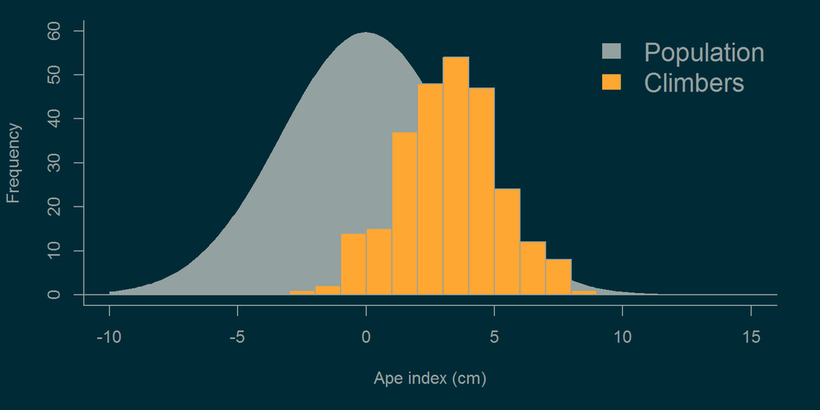

## Test of location

- First, we need to calculate the sample mean
- Then we need a measure of the distance between sample mean and expected $\mu$
- Taking all possible sample of *n* = 253 from the population of the null hypothesis (*e.g.,* climbers **are** from the general population), the differences between the sample means of the individual samples and the expected $\mu$ give us the sampling distribution of $\bar{x} - \mu$
- The sampling distribution will approach normal (according to [CLT](https://mivalek.github.io/Lectures/pub/l3_pub.html#/central-limit-theorem))

## Test of location

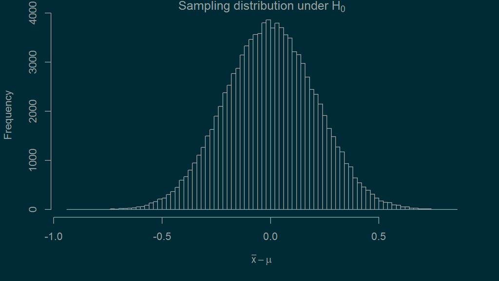

```r
n <- 253; mu <- 0; sigma <- 3.34
# for 100,000 samples get sample mean - mu
diff <- replicate(10^5, mean(rnorm(n, mu, sigma)) - mu)
hist(diff, breaks = 100, xlab = expression(bar(x)-mu),
     main = expression(Sampling~distribution~under~H[0]))
```

## Test of location

- The *SD* of the sampling distribution is the *SE* of the difference $\bar{x} - \mu$
- $SE = \sigma /\sqrt{n}$

```r
# close enough!
sd(diff)
[1] 0.2101372
(se <- sigma/sqrt(n))
[1] 0.209984
```

## Test of location

- Scaling the sampling distribution by *SE* turns it into **standard** normal (mean = 0, *SD* = 1)

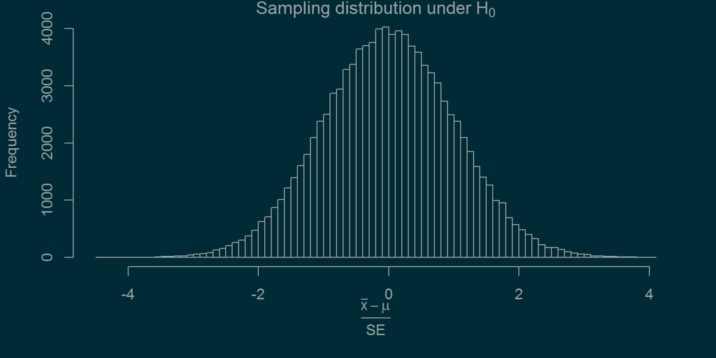

```r
diff_scale <- diff/se
hist(diff_scale, breaks = 100, xlab = expression(frac(bar(x)-mu, SE)),
     main = expression(Sampling~distribution~under~H[0]))
```

## Test of location

- We can also divide our measured difference by *SE* to get the *z*-statistic
  - $z = \frac{\bar{x}-\mu}{SE}$
- All that’s left is to find value of *z* in the sampling distribution and associated *p*-value

```r
(z <- (mean(climb) - mu)/se)
[1] 15.41326
# empirical 2-tailed p-value
sum(abs(diff_scale) >= z)/length(diff_scale)
[1] 0
# 2-tailed p-value using std normal distribution
pnorm(z, 0, 1, lower.tail = F) * 2
[1] 1.333109e-53
```

## Test of location

- $p = 1.33\times 10^{-53}$ – result is *highly statistically significant* so we reject $H_0$

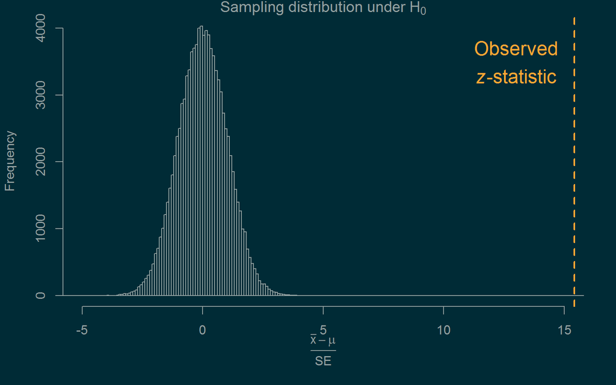

## Mean differences

- Slightly modified *z*-test can be used for comparing 2 groups on some *continuous* variable, if population variances are known
- AI is also predictive of performance in swimmers (Michael Phelps has the same arm span/height ratio as Ashima)
- Who has a larger mean AI, climbers or swimmers?
- $H:$ There is a difference in mean AI between elite climbers and elite swimmers – $\bar{x}_1 \ne \bar{x}_2$
- $H_0:$ Elite climbers and elite swimmers have the same mean AI – $\bar{x}_1 = \bar{x}_2$

## Mean differences

```r
# get 300 elite swimmers
swim <- rnorm(300, 3.32, 1.5)
```

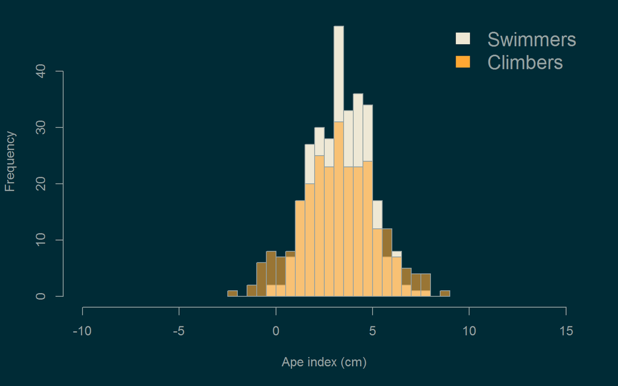

## Mean differences

- Again, the sampling distribution of the mean differences scaled by its *SE* is a standard normal distribution
- *z* statistic is used to get *p*-values
- $SE = \sqrt{\sigma_1^2/n_1 + \sigma_2^2/n_2}$
- $z = \frac{(\bar{x}_1 - \bar{x}_2) - (\mu_1 - \mu_2)}{SE}$
- Under $H_0$, there is no difference between population means, so $\mu_1 - \mu_2 = 0$

```r
var_climb <- 1.94^2
var_swim <- 1.5^2
(z <- (mean(climb) - mean(swim))/
    sqrt(var_climb/length(climb) + var_swim/length(swim)))
[1] -1.079301
pnorm(abs(z), lower.tail = F) * 2
[1] 0.2804534
```

## Mean differences

[(full code)](https://mivalek.github.io/Lectures/pub/error_bar_plot.R)

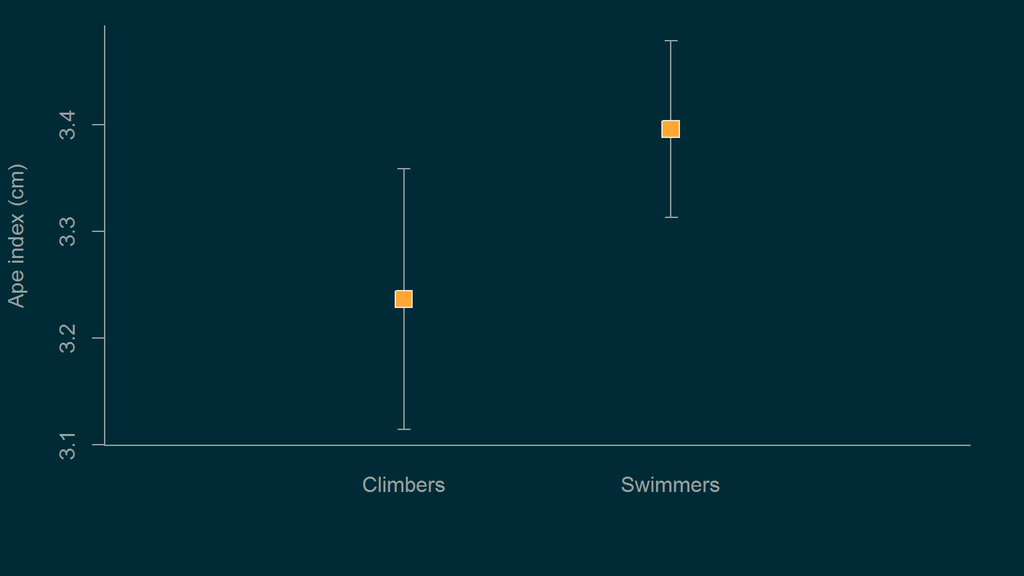

We found **no difference between the mean AI** of elite climbers and elite swimmers, $z = -1.08,\ p = .28$.

# Student’s *t* -test

## **Un**known $\sigma^2$

- When doing a *z*-test, we were scaling the difference between expected value and observed value by *SE*
- *SE* is calculated using population variance (or *SD*)
- What is the problem?
  - We don’t know $\sigma^2$ so we can’t calculate *SE*!

## Estimating *SE*

- We know we can estimate *SE* from **sample variance** as $\widehat{SE} = \sqrt{\frac{s^2}{n}}$
- $\widehat{SE}$ will be *different in every sample* – it’s a **variable**, while $SE$ is a **single number**
- $\widehat{SE}$ is based on sum of squares
  - What is its distribution?
  - $\chi^2$ with $n - 1$ degrees of freedom

## Estimating *SE*

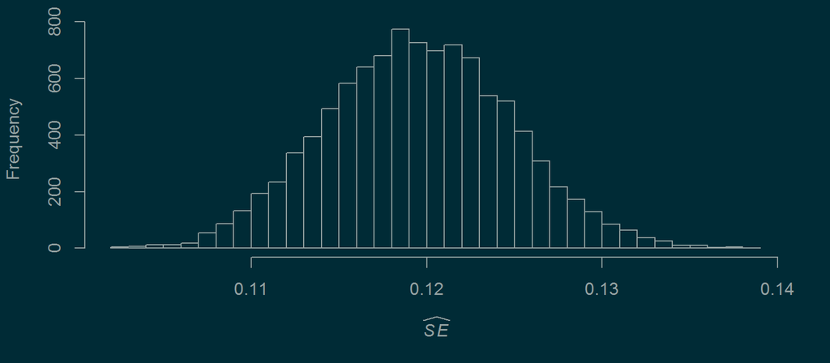

```r
n <- 263
# SE estimates from population of climbers with mu = 3 and sigma = 1.94
se_hat <- replicate(10^4, sd(rnorm(n, 3, 1.94))/sqrt(n))
mean(se_hat) # mean of the sampling dist of SE hat
[1] 0.1195214
1.94/sqrt(n) # compare to actual SE
[1] 0.1196255
hist(se_hat, breaks = 50,
     xlab = expression(widehat(italic(SE))), main = "")
```

## Test of location – unknown $\sigma^2$

- When population variance (and therefore *SE*) is unknown, we can’t calculate $z = \frac{\bar{x} - \mu}{SE}$
- We can substitute for *SE*, $\frac{\bar{x} - \mu}{\widehat{SE}}$
- What is the sampling distribution of $\bar{x} - \mu$?
  - If $\bar{x} - \mu$ is distributed normally and $\widehat{SE}$ according to $\chi^2$ with $n - 1$ degrees of freedom, what is the distribution of $\frac{\bar{x} - \mu}{\widehat{SE}}$?
  - *t*-distribution with $df = n-1$
- This is the formula for **one sample *t*-test**

## One sample *t* -test

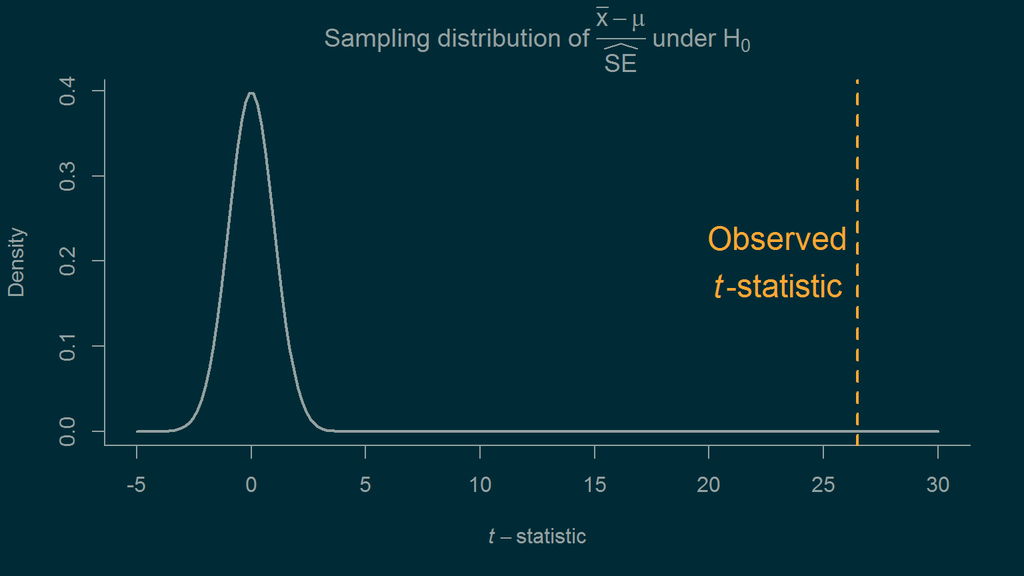

```r
se_hat <- sqrt(var(climb)/ n) # estimated SE
t <- mean(climb)/se_hat # t-statistic
pt(t, n - 1, lower.tail = F) * 2 # 2-tailed p-value
[1] 5.16621e-76
```

## One sample *t* -test

```r
t.test(climb) # one-sample t-test (mu = 0 by default)

    One Sample t-test

data:  climb
t = 26.473, df = 262, p-value < 2.2e-16
alternative hypothesis: true mean is not equal to 0
95 percent confidence interval:
 2.995807 3.477270
sample estimates:
mean of x
 3.236538
```

A **one-sample *t*-test** showed that the mean ape index of elite climbers is significantly different from zero, $t(262) = 26.47,\ p = 5.17\times 10^{-76}$.

## Mean differences – unknown $\sigma^2$

- Logic behind one-sample *t*-test also applies to comparing differences in means of two groups
- Two scenarios for comparing groups
  - Observations across groups are unrelated - **independent *t*-test**
  - Observations are related (repeated measures, pairs of siblings *etc.*) - **paired samples *t*-test**

## Independent *t* -test

- Same idea as *z*-test for mean differences
  - $t = \frac{\bar{x}_1-\bar{x}_2}{combined\ \widehat{SE}}$ ([actual formulae](https://en.wikipedia.org/wiki/Student%27s_t-test#Independent_two-sample_t-test))
  - $df = n_1 + n_2 - 2$
- Let’s look at climbers vs swimmers again

## Independent *t* -test

- By default, `R` calculates [Welch’s t-test](https://en.wikipedia.org/wiki/Welch%27s_t-test)
  - Appropriate even if variances of the two samples are not equal
  - Notice slightly different number of *df*

```r
t.test(swim, climb)

    Welch Two Sample t-test

data:  swim and climb
t = 1.0795, df = 470.65, p-value = 0.2809
alternative hypothesis: true difference in means is not equal to 0
95 percent confidence interval:
 -0.1307397  0.4495286
sample estimates:
mean of x mean of y
 3.395933  3.236538
```

## Independent *t* -test

**Welch’s *t*-test** revealed no difference between the mean ape index of elite climbers and elite swimmers, $t(470.65) = 1.08,\ p = .281$.

## Paired samples *t* -test

- Used in repeated measures design or when pairs of observations are matched
- When individual data points across two group are related, independent *t*-test is not appropriate
  - Estimated pooled variance of the two groups is larger then the variance in differences between the matched points
- Which is faster in a 100 m race, front crawl or butterfly stroke?
  - 20 elite female swimmers completed two individual 100 m time trials using each of the styles (order was randomised)

## Paired samples *t* -test

- Times on individual efforts are strongly related

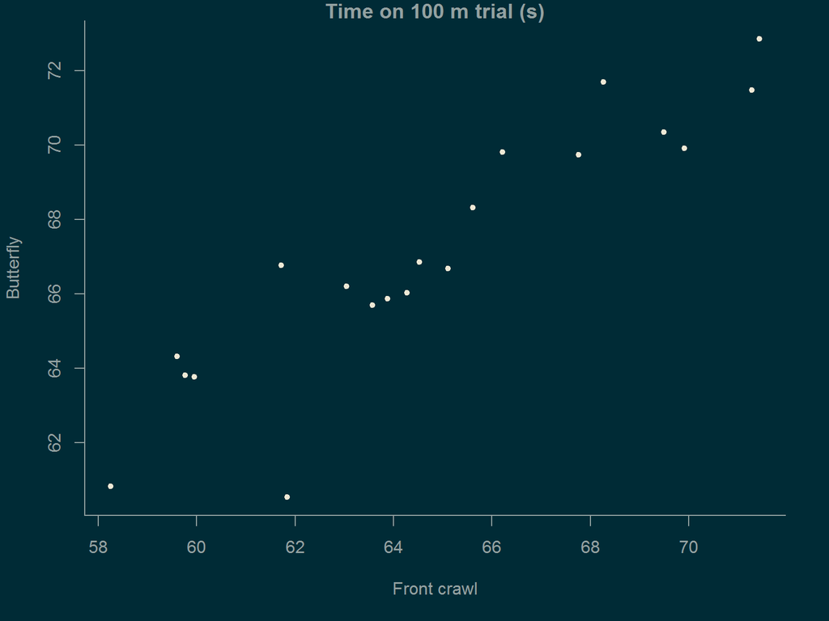

## Paired samples *t* -test

- Let’s try using independent *t*-test

```r
t.test(b_fly, crawl)

    Welch Two Sample t-test

data:  b_fly and crawl
t = 1.9557, df = 37.247, p-value = 0.05803
alternative hypothesis: true difference in means is not equal to 0
95 percent confidence interval:
 -0.0823304  4.6833950
sample estimates:
mean of x mean of y
 67.07590  64.77537
```

## Paired samples *t* -test

- We are interested in **mean difference** $\bar{x}_D$ between each swimmer’s crawl and fly efforts, not in **difference in means** of the two styles
- We want to scale by *SE* of the mean difference rather than by *pooled SE* of the groups
- $t = \frac{\bar{x}_D - \mu}{\sqrt{s^2_D/n}}$
- $H_0:\mu=0$
- $df = n-1$

## Paired samples *t* -test

- The numerator gives the same value as the one in independent *t*-test but the denominator doesn’t!

```r
# numerator
mean(b_fly - crawl) # paired
[1] 2.300532
mean(b_fly) - mean(crawl) # independent
[1] 2.300532
# denominator
sqrt(var(b_fly)/20 + var(crawl)/20) # SE Welch
[1] 1.176293
sqrt(var(b_fly - crawl)/20) # SE paired
[1] 0.3594874
```

## Paired samples *t* -test

- Result of independent *t*-test (actually, Welch’s *t*-test) was $t(37.247) = 1.956,\ p=.058$
- Let’s see what paired *t*-test tells us

```r
t.test(b_fly, crawl, paired = T)

    Paired t-test

data:  b_fly and crawl
t = 6.3995, df = 19, p-value = 3.885e-06
alternative hypothesis: true difference in means is not equal to 0
95 percent confidence interval:
 1.548117 3.052948
sample estimates:
mean of the differences
               2.300532
```

## Assumptions

- Both *z* and *t*-test requires the **numerator** ($\bar{x} - \mu$, $(\bar{x}_1 - \bar{x}_2) - (\mu_1 - \mu_2)$, or $\bar{x}_D - \mu$) to be normally distributed
- In addition, *t*-test assumes *SD* is independent of the numerator
- Independent *t*-test assumes both populations have equal variances ($\sigma^2_1 = \sigma^2_2$) but Welch’s test doesn’t
- *t*-test **does not** assume the data are normally distributed!
  - However, if they are, the above assumptions will be met

## Take-home message

- $\chi^2$-test is used to
  - assess *model fit*
  - see if data come from *specific distribution*
  - test for *independence of two categorical variables*
- *z*-test is used when population variance is known (almost never)
- *t*-test is used when population variance is *unknown*
  - **One sample** *t*-test is used as a *test of location*
  - **Independent** *t*-test is used for *comparing the means of two independent groups* (Welch’s test is always fine)
  - **Paired samples** *t*-test is used for *repeated measures* and *matched pairs* design

## Take-home message

All follow the same procedure

- Calculate test statistic
- Find value of test statistic in a corresponding distribution under $H_0$
- Calculate *p*-value that the test statistic is **at least as large** as the one observed, even if $H_0$ is true

# Decision errors

## False positives

- In [last lecture](https://mivalek.github.io/Lectures/pub/l4_pub.html#/the-problem-with-samples-1) we saw that even if there is no relationship in the population, we can still find one in the sample
- *p*-values tell us how likely we are to find a given or a more extreme result in a world where the null is true
- Sometimes, we can find a *statistically significant relationship*, even if there isn’t one in the population
- This is known as the **type I error** (AKA false positive)

## Type I error

- Type I error is a situation of rejecting the null, when it is in fact true
  - Jury convicting the defendant if they are innocent
  - Pregnancy test showing the person taking it is pregnant even if they are not
- There is **always** a chance that a significant result is due to Type I error
- Chance of committing Type I error is known as **$\alpha$ level** of the test
  - Conventionally, we want it to be **5%**
  - Related but not the same as *p*-value

## Type I error

- If $\alpha = .05$, we can expect *1/20 tests to reject the null hypothesis* even if it’s true

```r
# create 21 unrelated random normal variables
df_type1 <- data.frame(replicate(21, rnorm(40, 0, 1)))
# compare var 1 and each one of the 20 others with a t-test
results <- lapply(df_type1[-1, ], function(x) t.test(x, df_type1[[1]]))
```

## Type I error

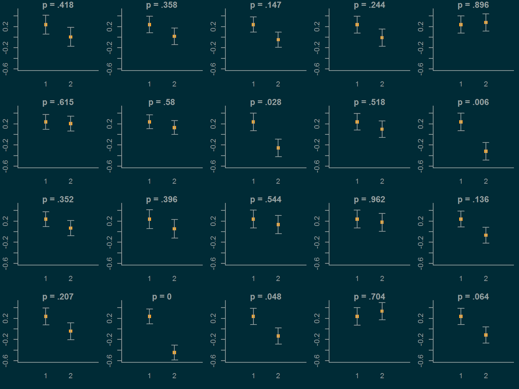

## Type I error

- Running repeated analyses on subsets of data **inflates** the chance of a significant result even if there is no relationship in the population
- *That is why it is bad practice to do studies like* [this one](https://xkcd.com/882/)

## False negatives

- Earlier, we saw that an independent *t*-test found no difference in times on 100 m trial between front crawl and butterfly, even though there was one
- When we fail to reject null if it really is false, we commit **type II error** (AKA false negative)
  - Jury acquitting the defendant even though they are guilty
  - Pregnancy test coming back negative, even if the person taking it is indeed [pregnant](https://www.youtube.com/watch?v=EShUeudtaFg)

## Type II error

- Chance of committing Type II error is known as **$\beta$ level** of the test
- $1 - \beta$ is then the **statistical power** of the test
  - Conventionally, we want it to be **at least 80%**
  - The larger the sample size, the higher the power
  - The larger the true population effect, the smaller the sample size needed to detect it
  - Different tests have different levels of power

## Type I and II error

|  | $H_0$ is true | $H_0$ is false |
| --- | --- | --- |
| $p \geq .05$ | Correct retention $1-\alpha$ | **Type II error** $\beta$ |
| $p < .05$ | **Type I error** $\alpha$ | Statistical power $1-\beta$ |

## Type I and II error

- There is always a trade-off between $\alpha$ and power
- The more conservative a test (small chance of committing type I error), the less power it has to detect a true effect
- Statistical power can be calculated *a priori* – check out [this interactive app](http://rpsychologist.com/d3/NHST/)
- *Always choose appropriate tests and a large enough sample to detect effect of a given size*

## What *p*-value is not

- We know that *p*-value denotes the probability that we get the **result we observed or a more extreme one** even if the null hypothesis is true
- *p*-value less than .05 does **not**
  - Disprove $H_0$
  - Show that there is a 5% probability that $H_0$ is true
  - Prove research hypothesis $H_1$
  - Calculate the probability of $H_1$ being true
  - Calculate the probability of your decision to reject $H_0$ being a Type I error
  - Show that repeating your experiment will give the same result 95% of the time

# Quantifying confidence

## Point vs interval estimates

- Tests we’ve covered only give us estimates of *single numbers* representing
  - departure from expectation ($\chi^2$)
  - differences between means (*z* and *t*)
  - mean difference between paired observations (*t*)
- There is **always** a degree of uncertainty around these *point estimates*
- It is very useful to quantify this uncertainty
- **Confidence intervals** are one way of achieving this

## Confidence intervals

- Suppose we ran our study comparing ape index of climbers and swimmers on *all possible samples*
- Each time, we would get a different point estimate (*t*) representing difference in means of the two groups
- The **true difference**, however, is always the same
- **x% confidence interval** is a range of values around each point estimate where x% of these ranges *include the true difference*
- 95% CIs are used most frequently but the level is arbitrary

## Confidence intervals

- For our independent *t*-test, 95% CI of the mean difference is [$-0.45,\ 0.13$]
- This is the range of values true difference can take **without being significantly different from the observed one** ($-0.16$)
- CIs that include zero *indicate non-significant results*

```r
df <- data.frame(group = rep(0:1, c(length(climb), length(swim))),
                 ape_index = c(climb, swim))
t.test(ape_index ~ group, df)

    Welch Two Sample t-test

data:  ape_index by group
t = -1.0795, df = 470.65, p-value = 0.2809
alternative hypothesis: true difference in means is not equal to 0
95 percent confidence interval:
 -0.4495286  0.1307397
sample estimates:
mean in group 0 mean in group 1
       3.236538        3.395933
```

## Confidence intervals

- Useful for plotting results [(full code)](https://mivalek.github.io/Lectures/pub/conf_int_plot.R)
- CI error bars overlapping with point estimates indicate non-significant result

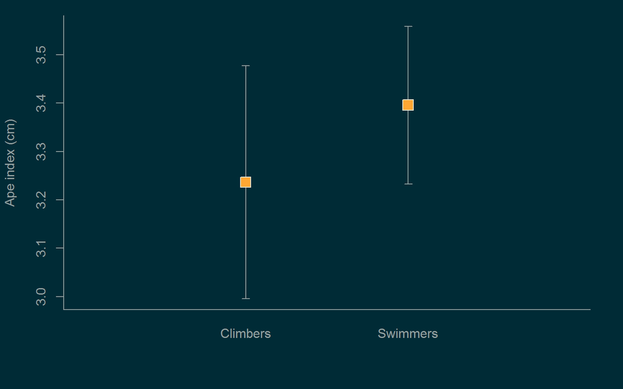

## Bootstrapping

- Ordinary CIs are, unsurprisingly, calculated using the *t*-statistic
  - This makes use of the fact that *t* is from a known distribution – $t(df = n-1)$
- If the distribution of the statistic is not known, we can use **resampling** methods to do inferential statistics
- **Bootstrapping** is a clever resampling method that’s easy to understand

## Bootstrapping

**The process**

1. Calculate the statistic of interest
2. Reshuffle your data by taking a sample of equal size **with replacement**
3. Re-calculate the statistic and save its value
4. Repeat 2. and 3. many times
5. Compare the original observed statistic to the empirical sampling distribution

## Bootstrapping *p* -values

- Let’s demonstrate bootstrapping on the difference in mean ape index between climbers and swimmers

```r
# observed statistic
obs_stat <- mean(df$ape_index[df$group == 0]) -
  mean(df$ape_index[df$group == 1])
# bootstrap
boot_dist <- c()
df2 <- df
for (i in 1:1000) {
  # RANDOMISE group by resampling its values
  df2$group <- sample(df$group, replace = T)
  boot_dist <- c( # add value to boot_dist
    boot_dist,
    # calculate the statistic on the bootstrapped sample
    mean(df2$ape_index[df2$group == 0]) -
      mean(df2$ape_index[df2$group == 1]))
}
```

## Bootstrapping *p* -values

- Now we can get the *p*-value based on the **empirical** sampling distribution

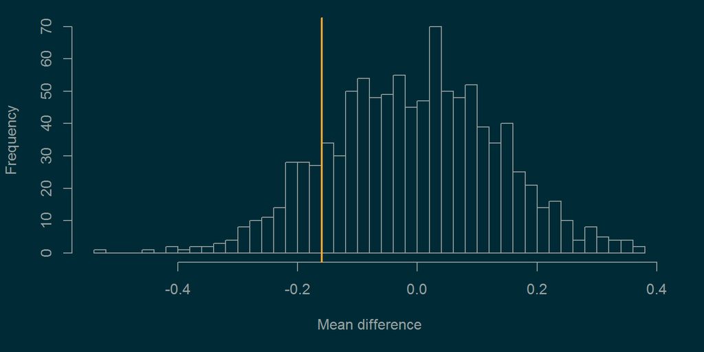

```r
sum(abs(boot_dist) >= abs(obs_stat)) / length(boot_dist)
[1] 0.255
t.test(ape_index ~ group, df)$p.value # compare to t-test
[1] 0.2808978
```

## Bootstrapping CIs

- Bootstrapping can be used to obtain CIs
- The difference in procedure is that we **don’t want to randomise** the data, just resample it
- In our case, that means that we won’t reshuffle `group` but take sample of whole rows of `df`

```r
# bootstrap for CI
boot_dist <- c()
for (i in 1:1000) {
  # resample df - ENTIRE ROWS
  df2 <- df[sample(nrow(df), replace = T), ]
  boot_dist <- c( # add value to boot_dist
    boot_dist,
    # calculate the statistic on the bootstrapped sample
    mean(df2$ape_index[df2$group == 0]) -
      mean(df2$ape_index[df2$group == 1]))
}
```

## Bootstrapping CIs

- The resulting empirical distribution is **centred around the original observed value**

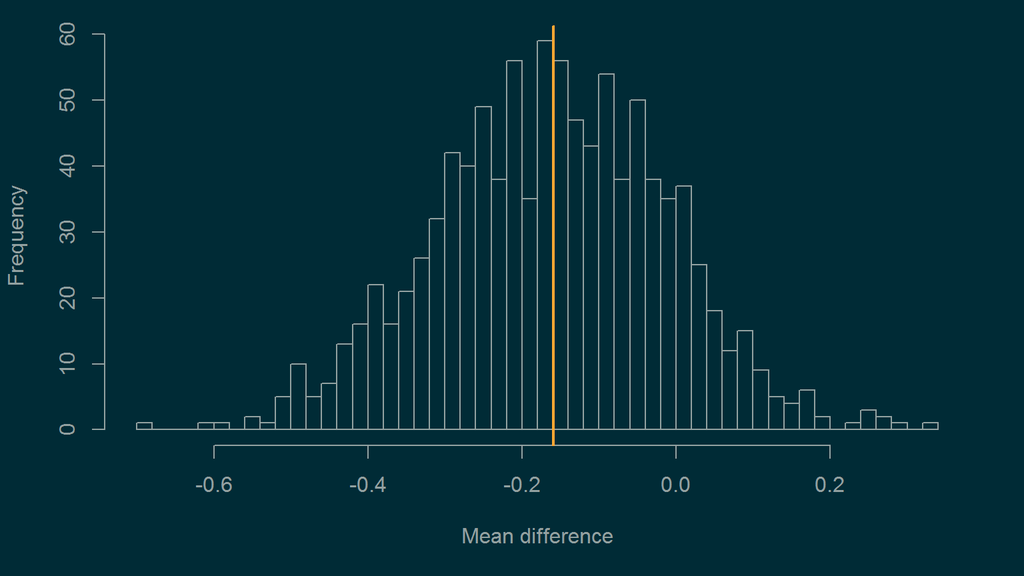

```r
hist(boot_dist, breaks = 50, main = "", xlab = "Mean difference")
abline(v = obs_stat, col = colors[3], lwd = 2)
```

## Bootstrapping CIs

- There are several methods for deriving bootstrapped CIs
- The simplest one (AKA *percentile bootstrap*) is to simply get the cut-off points corresponding to the middle 95% of the bootstrap distribution to get the bounds of the 95% CI
- This leads to **asymmetrical** CIs, other methods may produce symmetrical CIs

```r
# middle 95% of boot_dist = 95% CI
(cutoffs <- quantile(boot_dist, c(.025, .975), na.rm = T))
      2.5%      97.5%
-0.4629747  0.1197745

# compare to CI from t-test
t.test(ape_index ~ group, df[df$group != 2, ])$conf.int
[1] -0.4495286  0.1307397
attr(,"conf.level")
[1] 0.95
```

# Lines anyone?

## Mean difference as linear model

- Differences between means of two (or multiple) groups can be conceptualised as linear model
- Simplest way is using **dummy variables**
  - Let’s define variable **$D$** as a having the value of 0 for climbers and 1 for swimmers
- $\widehat{AI} = b_0 + b_1\times D$
- $\widehat{AI} = 3.24 + 0.16\times D$
- $\widehat{AI}_{climb} = 3.24 + 0.16\times 0 = 3.24$
- $\widehat{AI}_{swim} = 3.24 + 0.16\times 1 = 3.4$
- $b_1$ is then **the difference between the group means**

## Mean difference as linear model

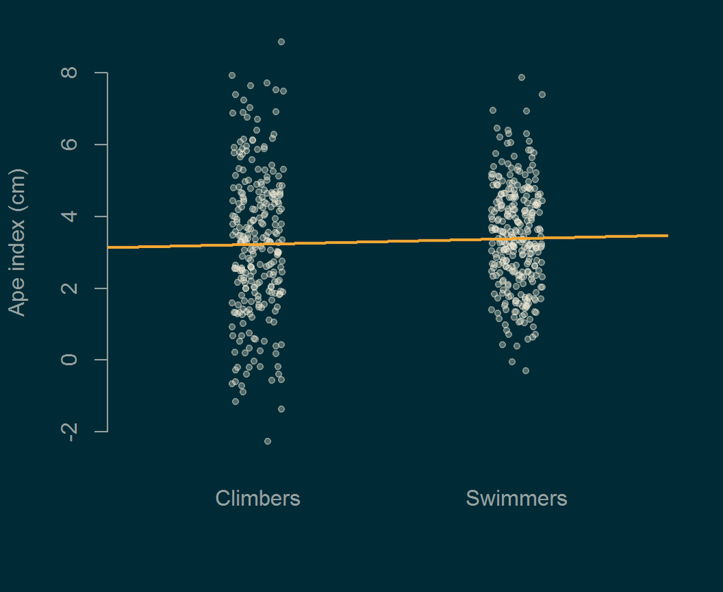

```r
df <- data.frame(group = rep(0:1, c(length(climb), length(swim))),
                 ape_index = c(climb, swim))
plot(ape_index ~ jitter(group, amount = .1), df, pch = 20, type = "p",
     col = paste0(colors[2], "55"), xlim = c(-.5, 1.5), bty = "n",
     xaxt = "n", xlab = "", ylab = "Ape index (cm)")
abline(lm(ape_index ~ group, df), lwd = 2, col = colors[3])
axis(1, at = 0:1, c("Climbers", "Swimmers"), tick = F, cex = 1.5)
```

## Mean difference as linear model

- Results of our *t*-test are equivalent to those of linear regression (Martin’s block)

```r
t.test(ape_index ~ group, df, var.equal = T) # Student's t not Welch's

    Two Sample t-test

data:  ape_index by group
t = -1.102, df = 561, p-value = 0.2709
alternative hypothesis: true difference in means is not equal to 0
95 percent confidence interval:
 -0.4434890  0.1247001
sample estimates:
mean in group 0 mean in group 1
       3.236538        3.395933
```

```r
# linear model
m1 <- lm(ape_index ~ group, df)
round(coef(summary(m1)),3) # summary of some of the results
            Estimate Std. Error t value Pr(>|t|)
(Intercept)    3.237      0.106  30.655    0.000
group          0.159      0.145   1.102    0.271
```

## More than 2 groups

```r
df_gen <- data.frame(group = 2, ape_index = rnorm(250, 0, 3.34))
df <- rbind(df, df_gen)
```

- Number of dummy variables needed is **one less** the number of groups
  - Let’s define variable **$D_1$** as having value of 1 for swimmers and 0 for everyone else
  - Let’s add variable **$D_2$** with value of 1 for general sample and 0 for everyone else

## More than 2 groups

```
    group  ape_index D_1 D_2
1       0  3.3222633   0   0
2       0  3.3758678   0   0
3       0  1.5576753   0   0
390     1  3.0198380   1   0
391     1  2.6463791   1   0
392     1  4.9876503   1   0
650     2  3.9600569   0   1
651     2 -0.0129005   0   1
652     2  4.5026731   0   1
```

## More than 2 groups

- $b_1$ is then the difference between means of **reference and first comparison** group
- $b_2$ is then the difference between means of **reference and second comparison** group

[figure not shown]

## More than 2 groups

- $b_1$ is then the difference between means of **reference and first comparison** group
- $b_2$ is then the difference between means of **reference and second comparison** group

[figure not shown]

## Take-home message

- Confidence intervals quantify the uncertainty around point estimates
- They give us **range of values** the true *population parameter* can take **and still not be significantly different from the *observed statistic***
- If they contain zero (for mean differences/slopes), result is not statistically significant
- If CI around mean of a group overlaps with mean of another group, groups are not significantly different

## Take-home message

- *Bootstrapping* is a simple but powerful and elegant **resampling method** of doing statistics
- **Relies on data alone**
- **Does not make assumptions** about parameter distributions
- It can be used to derive several types of CIs

## Take-home message

- Tests of location and mean differences **are** linear models with a *categorical predictor*
- Easiest way to include categorical predictors is using **dummy variables**
  - We need one fewer dummy variables than levels of categorical predictor
  - `R` does it by default when the predictor is a `factor`
- Intercept is the predicted mean of the *reference* category
- Individual *b* parameters related to dummy variables are differences in predicted means of reference and given comparison group